# Stage 1 DO Harmony Initial Data Load

Robert Sellers

The Jackson Laboratory

Last knit on: 17 May 2021

Document/Process explained:

- The following loads a “raw” bound object of all 96 well plates for an experiment. This data is available elsewhere as *do_focus_merge_2* for raw and metadata .csv / .tsv files.
- The resulting object list contains both the loaded data **all_plates** with **all_plates_clean** data.frames.
- A subset of curated features is also constructed / referenced as ‘harmony_do_focus_reduced.csv’.
- these objects can be simply loaded as follows:

```r
harmony_collection <- readRDS('./harmony_do_focus.RData')
analytics_csv <- read.csv('./harmony_do_focus_reduced.csv')
```

# 1 Environment

- Point your working directory to the project root folder

```r
# env
setwd('~/Desktop/projects/jax_arsenic_toxicology_analysis/')
options(scipen = 999) # suppress sci notation
# contains harmony plate collection class builder
source("scripts/harmony_utils.R")
# warehouse for functions
source("scripts/custom_tools.R")
require(dplyr)
```

# 2 Data

## 2.1 Direct load from .rdata or .csv

- Use this if not working with Harmony software data or development.

```r
harmony_collection <- readRDS('./harmony_do_focus.RData')
analytics_csv <- read.csv('./harmony_do_focus_reduced.csv')
```

## 2.2 Harmony_collection build (if applicable)

**The next two code blocks are optional / not knitted. This utility is a development tool.**

### 2.2.1 Build collection from raw option

- The following code block is set to eval=FALSE
- overwrite = TRUE builds a temp .rds file (e.g. temp_files/do_focus_merge_2.rds) from raw harmony data.

```r
# point to parent data directory
selected_dir <- "data/invitro/harmony_do_focus"
# Warning - this logic expects a ./temp_files data dir for caching
# Set overwrite to TRUE when underlying data dir has been changed
harmony_collection <- harmony_create_collection(dir = selected_dir,
                                                overwrite = TRUE,
                                                temp_dir = "./temp_files",
                                                custom_rename = FALSE)
```

### 2.2.2 Load collection from cache

```r
# point to parent data directory
selected_dir <- "data/invitro/harmony_do_focus"
# Warning - this currently expects a temp_files data dir
# Set overwrite to TRUE when underlying data dir has been changed
harmony_collection <- harmony_create_collection(dir = selected_dir,
                                                overwrite = FALSE,
                                                temp_dir = "./temp_files",
                                                custom_rename = FALSE)
```

# 3 Custom changes to data

## 3.1 Update logic

- Revised data is then added to the collection as harmony_collection$all_plates_clean

```r
# potentially universal updates for class creator
harmony_collection$all_plates_clean <- harmony_collection$all_plates %>%
  dplyr::rename(dose = concentration) %>%
  tibble::add_column(sex = NA, .after="individual") %>%
  dplyr::mutate(mouse = paste0(gsub('_','.',individual),"_", plate)) %>%
  dplyr::select(plate, row, column, dose, sex, individual, mouse, dplyr::everything())

# delete from dC20264_B1__20200928T12_28_55Measurement_1_e5 (Z)
# where rows are 6:8 and column is 9
# delete from dC20255_B2__20200926T13_00_37Measurement_2_e6 (Y)
# where rows are 1:6 and column is 10

# this needs a better standard / naming convention prior to analysis
excludes <- read.csv(text = "
dir,row,column
dC20264_B1__20200928T12_28_55Measurement_1_e5,6,9
dC20264_B1__20200928T12_28_55Measurement_1_e5,7,9
dC20264_B1__20200928T12_28_55Measurement_1_e5,8,9
dC20255_B2__20200926T13_00_37Measurement_2_e6,1,10
dC20255_B2__20200926T13_00_37Measurement_2_e6,2,10
dC20255_B2__20200926T13_00_37Measurement_2_e6,3,10
dC20255_B2__20200926T13_00_37Measurement_2_e6,4,10
dC20255_B2__20200926T13_00_37Measurement_2_e6,5,10
dC20255_B2__20200926T13_00_37Measurement_2_e6,6,10
")

harmony_collection$all_plates_clean <- dplyr::anti_join(harmony_collection$all_plates_clean, excludes)
```

```r
# unique data cleaning
harmony_collection$all_plates_clean <- harmony_collection$all_plates_clean %>%
  filter(
  dose != 0.5,
  individual != '11_20',
  individual != '5346') %>%
  # incorrect pairs
  mutate(plate=ifelse((dir=='dC20222_B2_rerun__20200829T11_01_59Measurement_4_e9'), 'B2', plate)) %>%
  mutate(plate=ifelse((dir=='d20222_B1_Cal__20200825T12_23_59Measurement_3_e6'), 'B1', plate)) %>%
  mutate(plate=ifelse((dir=='d20223_B2_Cal__20200817T11_02_00Measurement_1_e9'), 'A2', plate)) %>%
  mutate(plate=ifelse((dir=='d20223_A1_Cal__20200817T17_03_14Measurement_2_e7'), 'A1', plate)) %>%
  mutate(plate=ifelse((dir=='d20223_A2_Cal__20200818T14_54_58Measurement_1_e6'), 'B2', plate)) %>%
  mutate(plate=ifelse((dir=='d20223_B1_Cal__20200827T10_48_20Measurement_1_e7'), 'B1', plate)) %>%
  # incomplete pairs / ensuring completion of plate column
  mutate(plate=ifelse((dir=='dC20236_B2__20200828T14_45_19Measurement_1_e8'), 'B2', plate)) %>%
  mutate(plate=ifelse((dir=='dC20255_B1__20200925T14_41_51Measurement_5_e6'), 'B1', plate)) %>%
  mutate(plate=ifelse((dir=='dC20255_B2__20200926T13_00_37Measurement_2_e6'), 'B2', plate)) %>%
  mutate(plate=ifelse((dir=='dC20236_B1__20200828T13_12_27Measurement_1_e7'), 'B1', plate)) %>%
  mutate(plate=ifelse((dir=='dC20255_B2_last3columns__20200928T09_33_41Measurement_1_e7'), 'B2', plate)) %>%
  mutate(plate=ifelse((dir=='dC20264_B1__20200928T12_28_55Measurement_1_e5'), 'B1', plate)) %>%
  mutate(plate=ifelse((dir=='dW20267_A1__20201002T10_37_07Measurement_1_e5'), 'A1', plate)) %>%
  mutate(plate=ifelse((dir=='dW20267_A2__20201004T15_35_00Measurement_1_e5'), 'A2', plate)) %>%
  mutate(plate=ifelse((dir=='dW20267_B1__20201004T12_18_54Measurement_2_e5'), 'B1', plate)) %>%
  mutate(plate=ifelse((dir=='dW20267_B2__20201002T12_32_44Measurement_2_e5'), 'B2', plate)) %>%
  mutate(dir=ifelse((dir=='dC20255_B2_last3columns__20200928T09_33_41Measurement_1_e7'), 'dC20255_B2__20200926T13_00_37Measurement_2_e6', dir)) %>%
  mutate(dir=ifelse((dir=='dC20264_B1_last3__20200928T13_26_45Measurement_1_e5'), 'dC20264_B1__20200928T12_28_55Measurement_1_e5', dir)) %>%
  # hardcode mapped replicates to paired IDs
  # this throws an error
  mutate(group_pair = LETTERS702[group_indices(., substr(plate,1,1), sub("\\_.*", "", dir))]) %>%
  mutate(
    fdose = factor(dose),
    fdir = factor(dir)
    )
```

## 3.2 Notes on changes

- group_pairs with missing / removed well data
  - B (Individual 1882 instrument malfunction at corner of plate)
  - O (Individual 11_20 removed)
  - W (Individual 5346 removed due to naming error; data split between runs)
  - Y (Individual 5346 removed due to naming error; Individual 2213 instrument malfunction at corner of plate; Data split between runs)
  - Z (Data split between runs)

## 3.3 Additional new columns

- this is needed for some subsequent plotting

```r
# integer bin_id logic
# binary integer ID per plate pair (zero or 1)
# this is slow / inefficient
harmony_collection$all_plates_clean <- iterate_bin_id(harmony_collection$all_plates_clean)
```

## 3.4 Quick tables / plots

### 3.4.1 Counts per feature

```r
table(harmony_collection$all_plates_clean$group_pair, harmony_collection$all_plates_clean$bin_id)
```

```
##
##       0  1
##   A  96 96
##   AA 96 96
##   AB 96 96
##   AC 96 96
##   AD 96 96
##   AE 96 96
##   AF 96 96
##   AG 96 96
##   AH 96 96
##   AI 96 96
##   AJ 96 96
##   AK 96 96
##   AL 96 96
##   AM 96 96
##   AN 96 96
##   B  94 93
##   C  96 96
##   D  96 96
##   E  96 96
##   F  96 96
##   G  96 96
##   H  96 96
##   I  96 96
##   J  96 96
##   K  96 96
##   L  96 96
##   M  96 96
##   N  96 96
##   O  80 80
##   P  96 96
##   Q  96 96
##   R  96 96
##   S  96 96
##   T  96 96
##   U  96 96
##   V  96 96
##   W  79 80
##   X  96 96
##   Y  80 78
##   Z  96 96
```

### 3.4.2 Paired plot on example feature

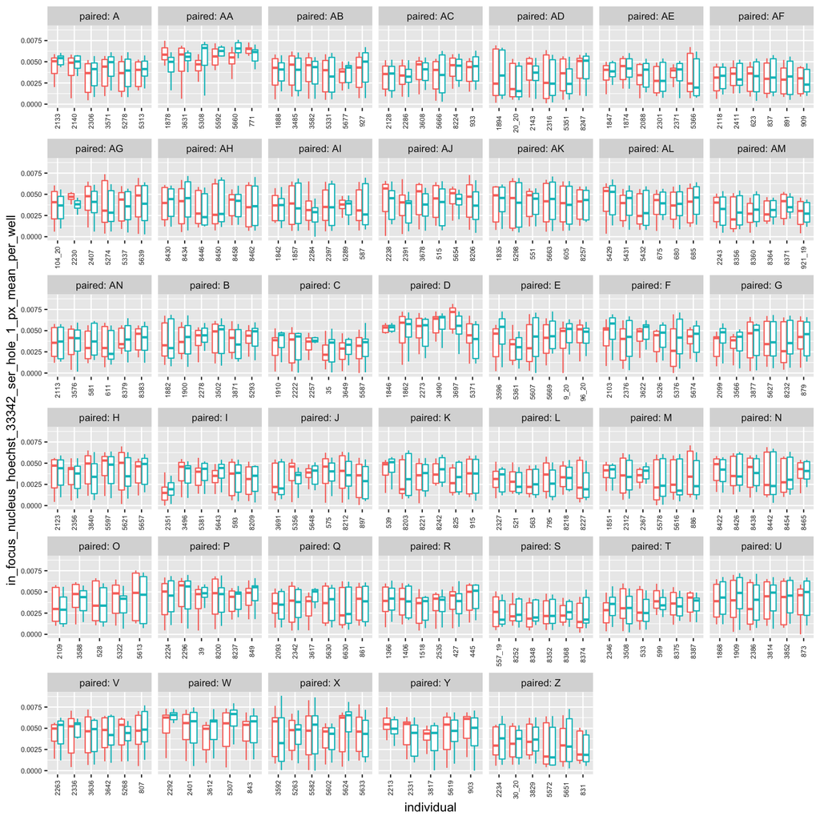

```r
boxplot_pairs(y ='in_focus_nucleus_hoechst_33342_ser_hole_1_px_mean_per_well',
              data = harmony_collection$all_plates_clean,
              filename = NA)
```

# 4 Saves

```r
# save over .rdata
saveRDS(harmony_collection, './harmony_do_focus.RData')
```

```r
# save corresponding .csv
# currently analyzing the following features
selected_features <- c(
  "nuclei_number_of_objects",
  "in_focus_cell_area_mm2_mean_per_well",
  "in_focus_intensity_cell_hoechst_33342_mean_mean_per_well",
  "in_focus_nucleus_hoechst_33342_ser_dark_1_px_mean_per_well",
  "in_focus_nucleus_hoechst_33342_ser_edge_1_px_mean_per_well",
  "in_focus_nucleus_hoechst_33342_ser_hole_1_px_mean_per_well",
  "in_focus_cell_mito_tracker_deep_red_ser_dark_1_px_mean_per_well",
  "in_focus_cell_mito_tracker_deep_red_ser_edge_1_px_mean_per_well",
  "in_focus_cell_mito_tracker_deep_red_ser_hole_1_px_mean_per_well",
  "in_focus_intensity_cell_mito_tracker_deep_red_mean_2_mean_per_well"
  )
```

```r
summary(harmony_collection$all_plates_clean[,
     c("dir","row","column","dose","individual","mouse",
       selected_features)])
```

```
##      dir                 row            column            dose
##  Length:7576        Min.   :1.000   Min.   : 1.000   Min.   :0.000
##  Class :character   1st Qu.:2.000   1st Qu.: 4.000   1st Qu.:0.010
##  Mode  :character   Median :4.000   Median : 6.000   Median :0.750
##                     Mean   :4.497   Mean   : 6.494   Mean   :1.262
##                     3rd Qu.:6.000   3rd Qu.: 9.000   3rd Qu.:1.250
##                     Max.   :8.000   Max.   :12.000   Max.   :5.000
##
##   individual           mouse           nuclei_number_of_objects
##  Length:7576        Length:7576        Min.   :   0.0
##  Class :character   Class :character   1st Qu.:  31.0
##  Mode  :character   Mode  :character   Median : 105.0
##                                        Mean   : 366.7
##                                        3rd Qu.: 442.0
##                                        Max.   :8286.0
##
##  in_focus_cell_area_mm2_mean_per_well
##  Min.   :  43.62
##  1st Qu.: 452.69
##  Median : 715.33
##  Mean   : 710.59
##  3rd Qu.: 953.46
##  Max.   :3341.52
##  NA's   :78
##  in_focus_intensity_cell_hoechst_33342_mean_mean_per_well
##  Min.   :  396.0
##  1st Qu.:  950.5
##  Median : 1272.3
##  Mean   : 1541.7
##  3rd Qu.: 1856.6
##  Max.   :12281.5
##  NA's   :78
##  in_focus_nucleus_hoechst_33342_ser_dark_1_px_mean_per_well
##  Min.   :0.00424
##  1st Qu.:0.02840
##  Median :0.03429
##  Mean   :0.03462
##  3rd Qu.:0.04120
##  Max.   :0.06273
##  NA's   :78
```

[output cut: 33 more lines]

```
##  Min.   :0.00000
##  1st Qu.:0.00764
##  Median :0.00913
##  Mean   :0.00926
##  3rd Qu.:0.01096
##  Max.   :0.02449
##  NA's   :78
##  in_focus_intensity_cell_mito_tracker_deep_red_mean_2_mean_per_well
##  Min.   :  670
##  1st Qu.: 2628
##  Median : 3423
##  Mean   : 3895
##  3rd Qu.: 4496
##  Max.   :41670
##  NA's   :78
```

```r
write.csv(harmony_collection$all_plates_clean[,
     c("dir","row","column","dose","individual","mouse",
       selected_features)], './harmony_do_focus_reduced.csv', row.names = FALSE)
```